### Equilibrage

```
0 => friche avec projet
1 => friche potentielle
2 => friche reconvertie
3 => friche sans projet
```

```
Counter({1: 10503, 3: 7019, 0: 4431, 2: 539})
```

```
Classification report :
               precision    recall  f1-score   support

           0       0.70      0.71      0.70      1107
           1       0.97      0.96      0.97      2626
           2       0.47      0.61      0.53       135
           3       0.78      0.77      0.77      1755

    accuracy                           0.84      5623
   macro avg       0.73      0.76      0.74      5623
weighted avg       0.85      0.84      0.84      5623
```

[figure not shown]

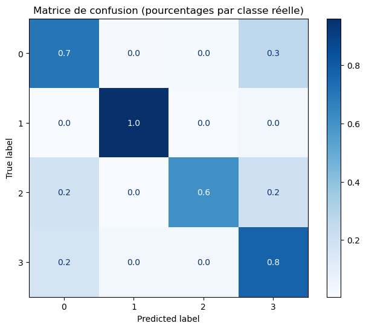

### Feature engineering élargissement du choix des features

ex feature utilisé par l'EPF pour la mutabilité Etat de la friche Surface de la parcelle: Emprise au sol du bâti État du bâti et infrastructure Présence de pollution Situation: En centre-ville ou centre-bourg Terrain viabilisé Distance d'une entrée d'autoroute Distance d'une gare/ TC Voie d'eau à proximité  
Commerces / services à proximité-Distance raccordement BT/HT  
Réglementation: Zonage PLU-Risque naturel Risque technologique Monument historique - Patrimoine Valeur architecturale  
Ecosystème Couvert: végétal Espèce protégée- Zonage environnemental- TVBZones humides

### Test sur les 50 variables toutes les modalités nan sont transformé en 0

```
Statistique du test du Chi² : 368.0570615521297
Degrés de liberté : 36
P-value : 1.1782490964730334e-56
✅ Conclusion : il existe une association significative entre le statut de la friche et son type de réhabilitation.
```

### bac a sable pour tester les features

```
                              precision    recall  f1-score   support

                           0       1.00      1.00      1.00      5155
 aménagement d'espace public       1.00      0.44      0.62         9
                       autre       1.00      0.43      0.60         7
autres activités économiques       0.90      0.83      0.86        69
                      bureau       0.50      0.29      0.36         7
                    commerce       0.67      0.35      0.46        17
                     habitat       0.83      1.00      0.91       215
                   industrie       0.00      0.00      0.00         7
                       mixte       0.85      0.90      0.87        68
    panneaux photovoltaiques       0.67      0.40      0.50         5
                renaturation       1.00      0.47      0.64        17
           équipement public       0.92      0.74      0.82        47

                    accuracy                           0.99      5623
                   macro avg       0.78      0.57      0.64      5623
                weighted avg       0.99      0.99      0.98      5623
```

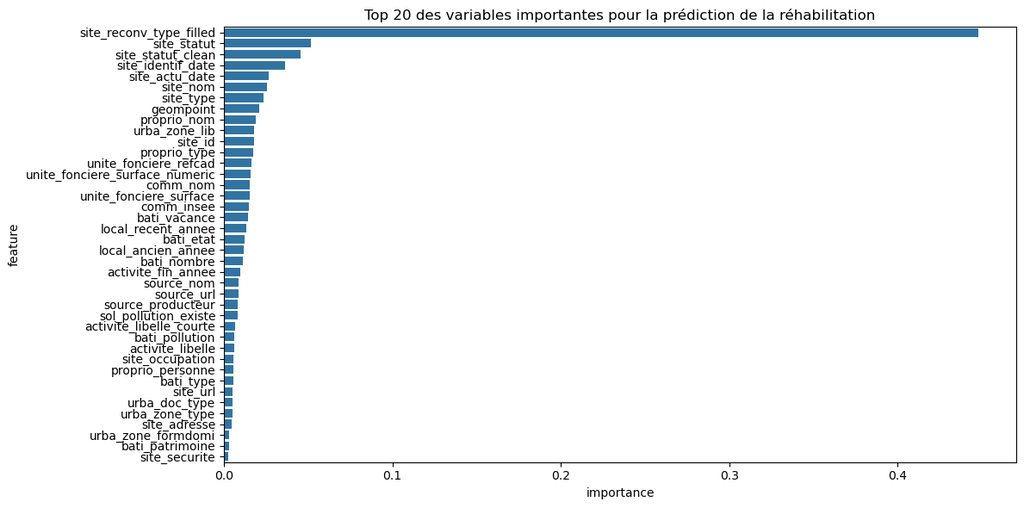

⚠️Revoir signification feature importance ou utilisé SHAP pour l'importance des features

### Cramer

```
dtype('<M8[ns]')
```

|  | CramersV |
| --- | --- |
| site_statut | 0.366548 |
| site_url | 0.282419 |
| bati_vacance | 0.238366 |
| site_identif_date | 0.213984 |
| site_actu_date | 0.210805 |
| sol_pollution_existe | 0.208197 |
| bati_pollution | 0.185145 |
| bati_etat | 0.143996 |
| site_securite | 0.140755 |
| site_type | 0.135850 |
| source_producteur | 0.135327 |
| source_nom | 0.135327 |
| source_url | 0.127258 |
| bati_type | 0.123535 |
| source_contact | 0.097509 |
| site_occupation | 0.096074 |
| site_adresse | 0.092132 |
| unite_fonciere_refcad | 0.089957 |
| proprio_personne | 0.086980 |
| bati_patrimoine | 0.086286 |
| comm_nom | 0.083733 |
| proprio_type | 0.082750 |
| comm_insee | 0.082257 |
| activite_fin_annee | 0.075859 |
| urba_zone_lib | 0.070383 |
| activite_libelle | 0.065840 |
| proprio_nom | 0.058338 |
| activite_code | 0.056930 |
| urba_zone_type | 0.047622 |
| urba_zone_formdomi | 0.030011 |
| urba_doc_type | 0.028956 |
| site_nom | 0.000000 |
| sol_depollution_fiche | 0.000000 |
| sol_pollution_origine | 0.000000 |
| site_id | NaN |
| geompoint | NaN |

🔎 Lecture structurée 🔝 Variables fortement corrélées avec la cible `site_statut` (0.366) → cohérent, c’est souvent la variable cible ou une proche.

`site_url` (0.282) → étrange à première vue ; possible effet structurel (présence d’un site Web liée à des friches plus avancées ?).

`bati_vacance` (0.238), `sol_pollution_existe` (0.208), `bati_pollution` (0.185), `site_securite` (0.141) → toutes très pertinentes sur le degré de délabrement ou d’abandon.

Ces variables peuvent avoir une valeur explicative directe pour un modèle de classification du statut.

📉 Variables faiblement corrélées `urba_zone_formdomi`, `urba_doc_type`, `proprio_nom`, etc. → faible Cramér’s V : à ne garder que si elles ont un intérêt métier, ou si elles se croisent bien avec d’autres.

⚠️ Variables à 0 `site_nom`, `sol_depollution_fiche`, `sol_pollution_origine` → attention, soit :

elles n’ont aucune variation significative liée à la cible ;

soit leur encodage ou nettoyage a masqué les signaux.

❓ Variables à NaN (non traitées) `site_id`, `geompoint` → normal, ce sont des identifiants ou coordonnées.

➤ À exclure d’office de toute analyse statistique directe.

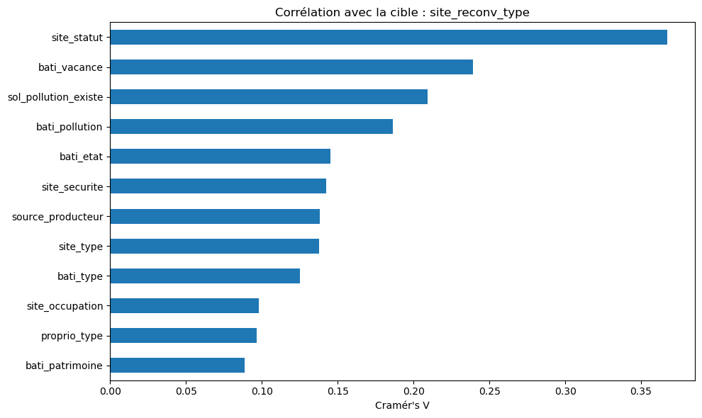

|  | Variable | p_value |
| --- | --- | --- |
| 9 | unite_fonciere_surface | 5.494540e-67 |
| 3 | bati_nombre | 1.937577e-59 |
| 6 | local_recent_annee | 2.165487e-30 |
| 5 | local_ancien_annee | 6.347834e-27 |
| 0 | site_ademe_url | NaN |
| 1 | site_projet_url | NaN |
| 2 | site_reconv_annee | NaN |
| 4 | bati_surface | NaN |
| 7 | sol_pollution_annee | NaN |
| 8 | sol_pollution_commentaire | NaN |
| 10 | desserte_distance | NaN |
| 11 | desserte_commentaire | NaN |
| 12 | geomsurf | NaN |

```
site_reconv_type              0
site_statut                   0
site_url                      0
bati_vacance                  0
sol_pollution_existe          0
bati_pollution                0
bati_etat                     0
site_securite                 0
site_type                     0
source_producteur             0
source_nom                    0
bati_type                     0
site_occupation               0
unite_fonciere_surface       63
bati_nombre                  66
local_recent_annee        10694
local_ancien_annee        12772
dtype: int64
```

```
site_url
inconnu                                                                                                                                                         11120
https://www.suippes.fr/9143-2/                                                                                                                                     14
https://fiches-risques.brgm.fr/georisques/basias-detaillee/LRO6602417                                                                                              13
https://fiches-risques.brgm.fr/georisques/basias-detaillee/NA                                                                                                      10
https://www.google.com/maps/@45.5922396,0.1766609,3a,72.8y,317.09h,84.27t/data=!3m6!1e1!3m4!1smpDybbJGI3Por8GFLoUS9Q!2e0!7i13312!8i6656?authuser=0&entry=ttu        3
                                                                                                                                                                ...
https://fiches-risques.brgm.fr/georisques/basias-detaillee/LOR8800529                                                                                               1
http://fiches-risques.brgm.fr/georisques/basias-detaillee/PAC0501872                                                                                                1
https://basol.developpement-durable.gouv.fr/fiche.php?page=1&index_sp=87.0031                                                                                       1
http://fiches-risques.brgm.fr/georisques/basias-detaillee/LRO6602561                                                                                                1
http://fiches-risques.brgm.fr/georisques/basias-detaillee/BRE3503237                                                                                                1
Name: count, Length: 16940, dtype: int64
```

## 📖 Synthèse sur la qualité des données

### Complétude

```
--- Début de l’analyse de complétude détaillée ---

🔍 Domaine : information
  • site_id : 100.0%
  • site_nom : 100.0%
  • site_type : 38.7%
  • site_statut : 100.0%
  • site_occupation : 8.1%
  • site_reconv_type : 8.5%

🔍 Domaine : temporel
  • site_identif_date : 100.0%
  • site_actu_date : 100.0%
  • site_reconv_annee : 0.0%
  • activite_fin_annee : 14.2%
  • local_ancien_annee : 54.6%
  • local_recent_annee : 62.0%

🔍 Domaine : localisation
  • comm_nom : 99.5%
  • comm_insee : 99.5%
  • geompoint : 100.0%
  • geomsurf : 0.0%
  • site_adresse : 14.2%

🔍 Domaine : bati
  • bati_type : 7.6%
  • bati_nombre : 99.8%
  • bati_surface : 0.1%
  • bati_vacance : 7.5%
  • bati_patrimoine : 10.0%
  • bati_etat : 20.6%
  • unite_fonciere_surface : 99.8%
  • unite_fonciere_refcad : 99.9%

🔍 Domaine : proprietaire
  • proprio_type : 98.9%
  • proprio_personne : 99.8%
  • proprio_nom : 98.9%
  • activite_libelle : 52.0%
  • activite_code : 0.5%

🔍 Domaine : pollution
  • sol_pollution_annee : 0.0%
  • sol_pollution_existe : 11.7%
  • sol_pollution_origine : 0.1%
  • sol_pollution_commentaire : 0.0%
  • sol_depollution_fiche : 0.0%
  • site_securite : 79.3%
  • bati_pollution : 4.4%

🔍 Domaine : urbanisme
  • urba_zone_type : 85.9%
  • urba_zone_lib : 85.9%
  • urba_zone_formdomi : 16.1%
  • urba_doc_type : 86.3%
  • desserte_distance : 0.0%
  • desserte_commentaire : 0.0%

🔍 Domaine : source
  • source_nom : 17.9%
  • source_url : 76.4%
  • source_producteur : 23.4%
  • source_contact : 8.3%
  • site_url : 60.4%
  • site_ademe_url : 0.0%
  • site_projet_url : 0.0%

✅ 50 colonnes analysées.
```

[interactive chart not shown]

### Criticité

[interactive chart not shown]

### Unicité

[interactive chart not shown]